# Data Package Checks Report

This report was created on 2026-02-07 by brieanne-forbes.

Data Package: **rcsfa-data_processing_for_publication**

> **Your data package passed 0 of 1 required test(s).**

> **Your data package passed 5 of 6 strongly recommended test(s).**

Authors, domain experts, and the data management team must still review the data and make context-specific decisions, including confirming the correct **land and funding acknowledgements**, before publishing.

## Did your data package pass?

The data quality checks help data packages comply with the best practices for accessibility and usability. The data checks are not intended to interpret the meaning of the data, assess scientific validity, fix issues that were detected, or replace human judgement.

**Review any flagged items in the visualizations or tables, make corrections as needed (e.g., add missing files, replace proprietary files, rename columns, or remove duplicates), and re-run the checks to confirm compliance.**

### Overview

- Required checks are required to pass before a data package will be published.
- Recommended checks are suggested to pass before a data package will be published. Passing `strongly recommended` checks prepares your data package to be included into ESS-DIVE’s Fusion Database, allowing your data and scripts to be searchable within the deep dive API search tool.
- The RC-SFA project expects that all Study Data Packages adhere to both `required` and `strongly recommended` checks. Manuscript Data Packages must adhere to the `required` checks and are encouraged to consider the `strongly recommended` checks.

[output not shown]

### `includes required files`

> **Your data package is missing 3 required file(s).**

In addition to your data files, we require a file-level metadata file (FLMD), data dictionary (DD), and readme in each data package. Proprietary files should be converted to non-proprietary options (e.g., .docx are converted to .pdf). To improve interoperability with ESS-DIVE’s tools, these three file have specific file naming conventions.

| pass_check | required_file | file |
| --- | --- | --- |
| FAILED | FLMD | file not found |
| FAILED | DD | file not found |
| FAILED | readme | file not found |

### `no proprietary files`

> **Your data package has 0 proprietary file(s).**

ESS-DIVE requests that all files are saved in a non-proprietary file format. While not exhaustive, this check confirms that the following common proprietary extensions are not included: docx, doc, xlsx, pptx, ppt, m, fig, mat, mlx, p, mdl

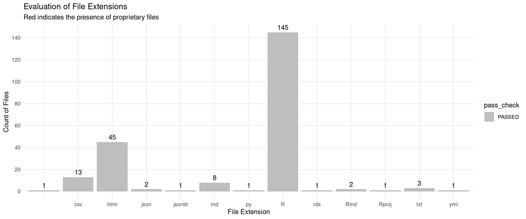

### `no special characters`

> **Your data package has 5 special characters error(s).**

> **Your data package has 0 empty column header(s).**

Special characters are not allowed in folder names, file names, or column headers and will cause the check to fail.

- **`no special characters` in directory names**: The only characters allowed in folder names are lowercase letters, uppercase letters, numbers, underscores, periods, and hyphens.
- **`no special characters` in file names**: The only characters allowed in file names are lowercase letters, uppercase letters, numbers, underscores, periods, and hyphens.
- **`no special characters` in column headers**: The only characters allowed in tabular column headers are lowercase letters, uppercase letters, numbers, underscores, periods, and hyphens. It is recommended that columns begin with a letter.
- **`no empty column headers`**: Tabular data must be rectangular - each row should have the same number of columns and every column must have a column header.

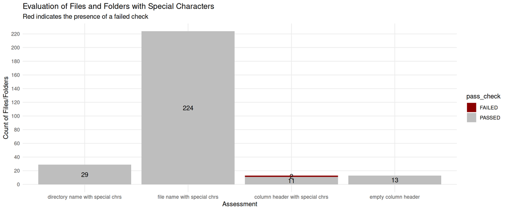

Cells marked with an ‘X’ in the table below indicate the presence of a special character

| special_character | directory_name | file_name | column_header |
| --- | --- | --- | --- |
| space |  |  | X |
| / |  |  | X |

### `no duplicate names`

> **Your data package has 0 file(s) that contain duplicate column names.**

Column names should be unique within each file. Column names can be repeated across files if they share the same definition.

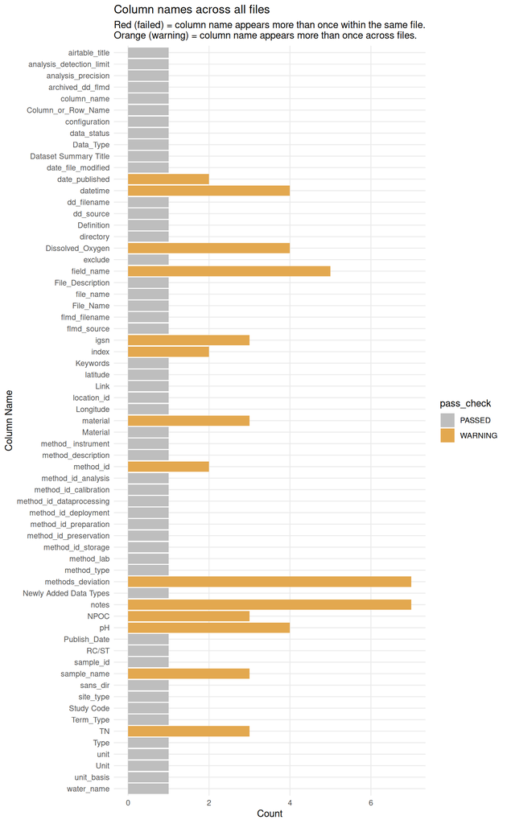

### Tabular Data

#### **Preview your tabular data:**

> **Number of files with negative values in your data package: 0**

This table summarizes tabular files in your data package to enable you to review each tabular data column for your own data quality concerns (e.g., anticipated ranges or avoiding negative values). Unlike the other tabs, this tab does not display discrete pass/fail data checks because the review enabled by this tab is based upon the individual data package needs as determined by the author/reviewer. It is up to you, as the data package author/reviewer, to check this table for any relevant data concerns.

**Each row in the table represents a single column from a tabular data file. Click to expand/collapse column definitions.**

- **`file_name`** = The name of the file where the column is found.
- **`column_name`** = The name of the column within the file.
- **`column_type`** = The data type of the column (e.g., character, numeric, logical, mixed, etc.)
- **`num_rows`** = The total number of rows in the column.
- **`num_unique_rows`** = The number of unique values present in the column. If this number is the same as `num_rows`, then all values are unique. If this number is less than `num_rows`, then there are duplicate values within the column.
- **`num_missing_values`** = The count of missing values in the column. **Check for missing data (the value should be 0 unless missing values are expected).**
- **`num_negative_values`** = The count of values less than 0 in the column (if column type is numeric or mixed).
- **`range_min`** = The minimum value in the column (if column is not character or logical). **If applicable, validate numeric ranges to ensure realistic values.**
- **`range_max`** = The maximum value in the column (if column is not character or logical). **If applicable, validate numeric ranges to ensure realistic values.**
- **`data_preview`** = A sampled preview of the top five most frequent values in the column, with the counts for each.

| file_name | column_name | column_type | num_rows | num_unique_rows | num_missing_values | num_empty_cells | num_negative_values | range_min | range_max | data_preview |
| --- | --- | --- | --- | --- | --- | --- | --- | --- | --- | --- |
| /Data_Package_Documentation/database/AirTable_DataPackagesInPipeline-PublishedBrief_as_of_2025-06-06.csv | Dataset Summary Title | character | 91 | 91 | 0 | 0 |  |  |  | 48 hour (n=1) --- Allison Veach AV1 (n=1) --- BSLE Processed OM (Myers-Pigg and Roebuck manuscripts) (n=1) --- BSLE Processed OM v2 (Myers-Pigg and Roebuck manuscripts) (n=1) --- BSLE Processed OM v3 … |
| /Data_Package_Documentation/database/AirTable_DataPackagesInPipeline-PublishedBrief_as_of_2025-06-06.csv | Study Code | character | 91 | 18 | 29 | 12 |  |  |  | S19S (n=13) --- SPS (n=9) --- BSLE (n=7) --- RC2 (n=5) --- CM (n=4) |
| /Data_Package_Documentation/database/AirTable_DataPackagesInPipeline-PublishedBrief_as_of_2025-06-06.csv | Link | character | 91 | 55 | 0 | 0 |  |  |  | https://data.ess-dive.lbl.gov/datasets/doi:10.15485/1729719 (n=7) --- https://data.ess-dive.lbl.gov/datasets/doi:10.15485/1923689 (n=5) --- https://data.ess-dive.lbl.gov/datasets/doi:10.15485/1603775 … |
| /Data_Package_Documentation/database/AirTable_DataPackagesInPipeline-PublishedBrief_as_of_2025-06-06.csv | RC/ST | character | 91 | 7 | 2 | 2 |  |  |  | RC4 (n=32) --- RC2 (n=25) --- RC3 (n=16) --- RC1 (n=8) --- All SFA (n=4) |
| /Data_Package_Documentation/database/AirTable_DataPackagesInPipeline-PublishedBrief_as_of_2025-06-06.csv | Type | character | 91 | 2 | 0 | 0 |  |  |  | Study (n=58) --- Manuscript (n=33) |
| /Data_Package_Documentation/database/AirTable_DataPackagesInPipeline-PublishedBrief_as_of_2025-06-06.csv | Material | character | 91 | 7 | 43 | 22 |  |  |  | Water (n=23) --- Sediment (n=10) --- Water,Sediment (n=8) --- Water,Solid chars (n=4) --- Water,Filter (n=2) |
| /Data_Package_Documentation/database/AirTable_DataPackagesInPipeline-PublishedBrief_as_of_2025-06-06.csv | Newly Added Data Types | character | 91 | 46 | 25 | 25 |  |  |  | Model data (n=7) --- Sensor (n=6) --- NPOC,Raw FTICR (n=5) --- Coordinates and COMIDs (n=4) --- C/N (n=2) |
| /Data_Package_Documentation/database/AirTable_DataPackagesInPipeline-PublishedBrief_as_of_2025-06-06.csv | Publish_Date | mixed | 91 | 69 | 4 | 4 | 0 | 1 | 12 | 11/11/2022 (n=3) --- 11/14/2023 (n=3) --- 4/28/2025 (n=3) --- 6/21/2023 (n=3) --- 1/27/2025 (n=2) |
| /Data_Package_Documentation/database/AirTable_DataPackagesInPipeline-PublishedBrief_as_of_2025-06-06.csv | Keywords | character | 91 | 6 | 69 | 69 |  |  |  | Lab incubation respiration (n=13) --- ERwc (n=6) --- ERsed (n=1) --- ERsed,ERtot,ERwc (n=1) --- ERtot (n=1) |
| /Data_Package_Documentation/database/All_dd_flmd_as_of_2025-06-05.csv | archived_dd_flmd | character | 119 | 119 | 0 | 0 |  |  |  | Z:/00_ESSDIVE/01_Study_DPs/00_ARCHIVE-WHEN-PUBLISHED/2023_04_Roebuck/SPS_Roebuck_Data_Package/SPS_Roebuck_dd.csv (n=1) --- Z:/00_ESSDIVE/01_Study_DPs/00_ARCHIVE-WHEN-PUBLISHED/2023_04_Roebuck/SPS_Roeb… |

[output cut: 93 more lines]

## Detailed Report

The Overview Table and tabs above assess the quality of your data. If any of the data checks failed, use the `Failed Checks` tab below to identify the actions you can take to troubleshoot specific problems.

1. Start with Overview Table (above). Focus on checks where `pass_check == "FAILED"` to locate critical issues first.
2. Then use the “Failed Checks” tab (below) to review the actions you can take to address the issue.
3. Correct the issues in your data files based, then re-run the checks to ensure all issues have been resolved.

### Failed Checks

**Each row in the table represents a failed check. Click to expand/collapse column definitions.**

- **`assessment`** = Describes the type of data validation or check being performed.
- **`action`** = Specifies the action or change required to resolve the issue.
- **`requirement`** = Indicates the level of importance or necessity for addressing the issue.
- **`input`** = Refers to the specific input text that caused the check to fail.
- **`file`** = Lists the file that contains the issue, providing context for where the problem exists.

| assessment | action | requirement | input | file |
| --- | --- | --- | --- | --- |
| includes required files | Add a FLMD to your data package. | required | file not found |  |
| includes required files | Add a DD to your data package. | required | file not found |  |
| includes required files | Add a readme to your data package. | required | file not found |  |
| no special characters | Remove special characters (`space`) from the column header `Dataset Summary Title` in `AirTable_DataPackagesInPipeline-PublishedBrief_as_of_2025-06-06.csv`. | strongly recommended | column_header: Dataset Summary Title | AirTable_DataPackagesInPipeline-PublishedBrief_as_of_2025-06-06.csv |
| no special characters | Remove special characters (`space`) from the column header `Study Code` in `AirTable_DataPackagesInPipeline-PublishedBrief_as_of_2025-06-06.csv`. | strongly recommended | column_header: Study Code | AirTable_DataPackagesInPipeline-PublishedBrief_as_of_2025-06-06.csv |
| no special characters | Remove special characters (`/`) from the column header `RC/ST` in `AirTable_DataPackagesInPipeline-PublishedBrief_as_of_2025-06-06.csv`. | strongly recommended | column_header: RC/ST | AirTable_DataPackagesInPipeline-PublishedBrief_as_of_2025-06-06.csv |
| no special characters | Remove special characters (`space`) from the column header `Newly Added Data Types` in `AirTable_DataPackagesInPipeline-PublishedBrief_as_of_2025-06-06.csv`. | strongly recommended | column_header: Newly Added Data Types | AirTable_DataPackagesInPipeline-PublishedBrief_as_of_2025-06-06.csv |
| no special characters | Remove special characters (`space`) from the column header `method_ instrument` in `MethodFile_combined.csv`. | strongly recommended | column_header: method_ instrument | MethodFile_combined.csv |

### Passed Checks

**Each row in the table represents a passed check. Click to expand/collapse column definitions.**

- **`assessment`** = Describes the type of data validation or check being performed.
- **`requirement`** = Indicates the level of importance or necessity of the assessment passing.
- **`input`** = Refers to the specific input text that was evaluated.
- **`file`** = Lists the file that was evaluated, providing context for the assessment.

| assessment | requirement | input | file |
| --- | --- | --- | --- |
| no special characters | strongly recommended | directory_name: rcsfa-data_processing_for_publication | rcsfa-data_processing_for_publication |
| no special characters | strongly recommended | directory_name: /data_checks_reports | /data_checks_reports |
| no special characters | strongly recommended | file_name: Checks_Report_2025-07-28.html | Checks_Report_2025-07-28.html |
| no proprietary files | strongly recommended | file_name: Checks_Report_2025-07-28.html | Checks_Report_2025-07-28.html |
| no special characters | strongly recommended | file_name: Checks_Report_2025-07-29.html | Checks_Report_2025-07-29.html |
| no proprietary files | strongly recommended | file_name: Checks_Report_2025-07-29.html | Checks_Report_2025-07-29.html |
| no special characters | strongly recommended | file_name: Checks_Report_2025-07-30.html | Checks_Report_2025-07-30.html |
| no proprietary files | strongly recommended | file_name: Checks_Report_2025-07-30.html | Checks_Report_2025-07-30.html |
| no special characters | strongly recommended | file_name: Checks_Report_2025-08-01.html | Checks_Report_2025-08-01.html |
| no proprietary files | strongly recommended | file_name: Checks_Report_2025-08-01.html | Checks_Report_2025-08-01.html |

[output cut: 771 more lines]

### Directory Tree

Below is a list of all of your folders and files that were present when the report was generated.

```
## /home/runner/work/rcsfa-data_processing_for_publication/rcsfa-data_processing_for_publication
## ├── Data_Package_Documentation
## │   ├── Boye_RF_Formatting
## │   │   ├── 01_Combine_Data.R
## │   │   ├── 02_Boye_Formatting.R
## │   │   ├── 02_Boye_Formatting_ICR.R
## │   │   ├── 02_Boye_Formatting_ProcessedData.R
## │   │   ├── 03_Add_IGSN_To_Boye_Files.R
## │   │   ├── 04_Methods_Codes.R
## │   │   ├── 05_Boye_Summary_File_outlier_file.R
## │   │   ├── 05_Boye_Summary_File_outlier_flag.R
## │   │   ├── Archive
## │   │   │   ├── 03_Methods_Codes_RC2_SPS.R
## │   │   │   └── 04_Boye_Summary_File_RC2_SPS.R
## │   │   └── test-05_Boye_Summary_File_outlier_flag.R
## │   ├── Format_CoreMS_Outputs.R
## │   ├── Geocoding.R
## │   ├── Goldman_RF_Formatting
## │   │   ├── 01_Format_Sensor_Data.R
## │   │   └── 02_Installation_Methods.R
## │   ├── IGSN_Formatting
## │   │   ├── Add_IGSN_To_NonBoye_Files.R
## │   │   ├── Match_parent_IGSN_to_child.R
## │   │   ├── PRT_create_IGSN_child_spreadsheet.R
## │   │   ├── check_igsn_for_duplicates.R
## │   │   ├── check_metadata_for_duplicates.R
## │   │   ├── create_IGSN_child_spreadsheet.R
## │   │   ├── create_IGSN_parent_spreadsheet.R
## │   │   ├── format_igsn.R
## │   │   ├── igsn_for_landing_page.R
## │   │   └── recreate_SESAR_template.R
## │   ├── Reverse_Geocoding.R
## │   ├── create_flmd_dd.R
## │   ├── data_package_update_database.R
## │   ├── database
## │   │   ├── AirTable_DataPackagesInPipeline-PublishedBrief_as_of_2025-06-06.csv
## │   │   ├── All_dd_flmd_as_of_2025-06-05.csv
## │   │   ├── data_dictionary_database.csv
## │   │   └── file_level_metadata_database.csv
## │   ├── functions
```

[output cut: 206 more lines]

```
## │   ├── Checks_Report_2025-12-04.html
## │   ├── Checks_Report_2025-12-09.html
## │   ├── Checks_Report_2025-12-15.html
## │   ├── Checks_Report_2025-12-23.html
## │   ├── Checks_Report_2025-12-31.html
## │   ├── Checks_Report_2026-01-20.html
## │   ├── Checks_Report_2026-01-29.html
## │   ├── Checks_Report_2026-01-30.html
## │   ├── Checks_Report_2026-02-07_files
## │   │   └── figure-html
## │   │       ├── duplicate-names-1.png
## │   │       ├── proprietary-files-1.png
## │   │       └── special-characters-1.png
## │   └── checks_report.Rmd
## └── tips_for_working_with_data.md
```